# Supplementary materials to the paper “Predicting haemoglobin deferral using machine learning models: can we use the same prediction model across countries?”

Author

Amber Meulenbeld, Jarkko Toivonen, Tinus Brits, Ronel Swanevelder, Dorien de Clippel, Veerle Compernolle, Surendra Karki, Marijke Welvaert, Katja van den Hurk, Joost van Rosmalen, Emmanuel Lesaffre, Mart Janssen and Mikko Arvas

An interactive version of this supplement is available through: https://sanguinstats.github.io/model_transferability/

# R Initialization and defining general functions

**Loading libraries**

```r
library(stats)
library(randomForest)
library(ROCR)
library(kableExtra)
library(formatdown)
library(xgboost)
library(data.table)

# Functions

# function to transform a numeric to a string with a fixed nr of decimals
fix_decimals<-function(x, digits=2, big_mark=NULL) gsub('\\$', '', format_decimal(x, digits=digits, big_mark = big_mark))
```

**function: createDatasets()**

```r
createDatasets<-function(propdef=0, printresults=F){
  # function that creates three datasets: data_train, data_test, data_val
  # it returns the theoretical proportion of deferrals and the proportion of deferrals
  # in the training and test datasets (and all other settings)
  # PopMean is adapted to match propdef if this value is unequal to 0

  if(propdef!=0) { # set population mean to match the desired deferral rate
    pnorm(threshold, mean=PopMean, PopSd)
    fo<-function(x) (pnorm(threshold, mean=x, sqrt(PopSd^2+MeasSd^2))-propdef)^2
    PopMean <<- optimize(fo, c(0,2*PopMean))$minimum
    # print(threshold)
  }
  # simulate data
  true<-rnorm(n, mean=PopMean, sd=PopSd)
  meas1<-true+rnorm(n, mean=0, sd=MeasSd)
  dat<-as.data.frame(cbind(true, meas1))
  if (nr_meas>1) {
    for(i in 1:(nr_meas-1)) dat<-cbind(dat, true+rnorm(n, mean=0, MeasSd))
    dat$target<-(dat[,nr_meas+1]<threshold)*1
  } else { # only one measurement
    dat$target<-(dat$true<threshold)*1
  }
  dat$target<-as.factor(dat$target)
  colnames(dat)<-c("true", paste0("meas",1:nr_meas), "deferral")
  train<-sample(1:n, n*trainprop, replace=F)
  test<-sample((1:n)[!(1:n %in% train)], n*testprop, replace=F)
  val<-(1:n)[!(1:n %in% train) & !(1:n %in% test) ]
  data_train<<-dat[train,]
  data_test<<-dat[test,]
  data_val<<-dat[val,]
  if (printresults){
    print("Proportion deferrals")
    print(paste("theory:", pnorm(threshold, mean=PopMean, sqrt(PopSd^2+MeasSd^2))))
    print(paste("dataset overall:",sum(dat$deferral==1)/nrow(dat)))
    print(paste("ratio:",sum(dat$deferral==1)/nrow(dat)/pnorm(threshold, mean=PopMean, PopSd)))
    print("")
    print(paste("training  :", sum(data_train$deferral==1)/nrow(data_train)))
    print(paste("testing   :", sum(data_test$deferral==1)/nrow(data_test)))
    if(nrow(data_val)>0) print(paste("validation:", sum(data_val$deferral==1)/nrow(data_val)))
  } else {
    return(c(pnorm(threshold, mean=PopMean, sqrt(PopSd^2+MeasSd^2)), sum(data_train$deferral==1)/nrow(data_train),
      sum(data_test$deferral==1)/nrow(data_test) ))
  }
}
```

**function: createNewTestDataset()**

```r
createNewTestDataset<-function(){
  # function that creates a new test dataset: data_test
  # note that it does not adapt PopMean to the propdef (as this takes time)
  # it returns the theoretical proportion of deferrals and the proportion of deferrals

  true<-rnorm(n*testprop, mean=PopMean, sd=PopSd)
  meas1<-true+rnorm(n*testprop, mean=0, sd=MeasSd)
  dat<-as.data.frame(cbind(true, meas1))
  if (nr_meas>1) {
    for(i in 1:(nr_meas-1)) dat<-cbind(dat, true+rnorm(n*testprop, mean=0, MeasSd))
    dat$target<-(dat[,nr_meas+1]<threshold)*1
  } else { # only one measurement
    dat$target<-(dat$true<threshold)*1
  }
  dat$target<-as.factor(dat$target)
  colnames(dat)<-c("true", paste0("meas",1:nr_meas), "deferral")
  data_test<<-dat
  # return proportion of deferrals
  #return(sum(data_test$deferral==1)/nrow(data_test))
}
```

**function: analyseTrainingData()**

```r
analyseTrainingData<-function(){
  # fit RF model

  data_train <- setDT(data_train)
  labels <- data_train$deferral

  new_tr <- model.matrix(~.+0,data = data_train[,"meas1",with=F])

  labels <- as.numeric(labels)-1

  dtrain <- xgb.DMatrix(data = new_tr,label = labels)

  params <- list(booster = "gbtree", objective = "binary:logistic", eta=0.3, gamma=0, max_depth=6, min_child_weight=1, subsample=1, colsample_bytree=1)

#xgbcv <- xgb.cv( params = params, data = dtrain, nrounds = 100, nfold = 5, showsd = T, stratified = T, print.every.n = 10, early.stop.round = 20, maximize = F)

  xgb1 <- xgb.train (params = params, data = dtrain, nrounds = 100, print_every_n = 10, watchlist = c(train=dtrain),early_stopping_rounds = 10, maximize = F , eval_metric = "error")

  # calculate AUPR
  xgbpred <- predict(xgb1,dtrain)
  perf_train_data = prediction(xgbpred, data_train$deferral)
  train_aucpr = performance(perf_train_data, "aucpr")
  train_auc = performance(perf_train_data, "auc")

  return(c(train_aucpr@y.values[[1]],train_auc@y.values[[1]]))
}
```

**function: analyseTestData()**

```r
analyseTestData<-function(){
  data_test <- setDT(data_test)

  ts_label <- data_test$deferral

  new_ts <- model.matrix(~.+0,data = data_test[,"meas1",with=F])

  ts_label <- as.numeric(ts_label)-1

  dtest <- xgb.DMatrix(data = new_ts,label=ts_label)
  # calculate AUPR
  xgbpred_test <- predict(xgb1,dtest)
  perf_test_data = prediction(xgbpred_test, data_test$deferral)
  test_aucpr = performance(perf_test_data, "aucpr")
  test_auc = performance(perf_test_data, "auc")
  return(c(test_aucpr@y.values[[1]],test_auc@y.values[[1]]))
}
```

**function: doSimulation()**

```r
doSimulation<-function(nrsim=3){
  lp<-length(props)
  lm<-length(MeasSds)
  # define an array to store deferral rates per sample
  dsc <<-array(0,dim=c(nrsim,lp)) # training data
  dsc2<<-array(0,dim=c(nrsim,lp,lp,lm)) # test data
  # define array to store AUPR and ROC results per sample
  trdao <<-array(0,dim=c(nrsim,lp,2))  # training data
  tedao <<-array(0,dim=c(nrsim,lp,lp,lm,2)) # test data
  for (i in 1:nrsim){
    print(paste(i, "of", nrsim))
    for (j in 1:lp){ # for each level of deferral rate of donors create training dataset and model
      PopMean<<-PopMeans[j]
      MeasSd<<-MeasSds[1]
      d1 <- createDatasets(propdef=props[j])
      dsc[i,j]<<-sum(data_train$deferral==1)/nrow(data_train)
      trdao[i,j,]<<-analyseTrainingData()
      for (k in 1:lp){ # apply the trained model to a dataset for each level of deferral
        # and level of  measurement variation
        for (l in 1:lm){
          PopMean<<-PopMeans[k,l]
          MeasSd<<-MeasSds[l]
          createNewTestDataset()
          dsc2 [i,j,k,l]<<-sum(data_test$deferral==1)/nrow(data_test)
          tedao[i,j,k,l,]<<-analyseTestData()
        }
      }
    }
  }
}
```

**function: plotResultsorProportions()**

```r
plotResultsorProportions <- function(res, auind, aucor, calcMedian, plotResults, plotProportions, plotExchanged, plotboth){
# function to plot simulation results

  # set spacing in x values for plotting
  d<<-min(props)/12

  # Extract statistics from the stored simulation output
  for (l in 1:lm){
    eval(parse(text=paste0("auMean",l,"<<-matrix(0, nrow=lp, ncol=lp)")))
    eval(parse(text=paste0("auSd"  ,l,"<<-matrix(0, nrow=lp, ncol=lp)")))
    eval(parse(text=paste0("auUL"  ,l,"<<-matrix(0, nrow=lp, ncol=lp)")))
    eval(parse(text=paste0("auLL"  ,l,"<<-matrix(0, nrow=lp, ncol=lp)")))

    eval(parse(text=paste0("dscMean",l,"<<-matrix(0, nrow=lp, ncol=lp)")))
    eval(parse(text=paste0("dscSd"  ,l,"<<-matrix(0, nrow=lp, ncol=lp)")))
    eval(parse(text=paste0("dscUL"  ,l,"<<-matrix(0, nrow=lp, ncol=lp)")))
    eval(parse(text=paste0("dscLL"  ,l,"<<-matrix(0, nrow=lp, ncol=lp)")))
    for (i in 1:lp){
      for (j in 1:lp){
        eval(parse(text=paste0("auMean",l,"[i,j]<<-mean(tedao    [,i,j,",l,",auind])")))
        if(calcMedian) eval(parse(text=paste0("auMean",l,"[i,j]<-median(tedao    [,i,j,",l,",auind])")))
        eval(parse(text=paste0("auSd"  ,l,"[i,j]<<-sd(tedao      [,i,j,",l,",auind])")))
        eval(parse(text=paste0("auUL"  ,l,"[i,j]<<-quantile(tedao[,i,j,",l,",auind],.975)")))
        eval(parse(text=paste0("auLL"  ,l,"[i,j]<<-max(0,quantile(tedao[,i,j,",l,",auind],.025))")))
        if (auind==1 & aucor==T){ # calculated adjusted AUPR values
          eval(parse(text=paste0("auMean",l,"[i,j]<<-mean(tedao    [,i,j,",l,",auind]-dsc2[,i,j,",l,"])")))
          if(calcMedian) eval(parse(text=paste0("auMean",l,"[i,j]<-median(tedao    [,i,j,",l,",auind]-dsc2[,i,j,",l,"])")))
          eval(parse(text=paste0("auSd"  ,l,"[i,j]<<-sd(tedao      [,i,j,",l,",auind]-dsc2[,i,j,",l,"])")))
          eval(parse(text=paste0("auUL"  ,l,"[i,j]<<-quantile(tedao[,i,j,",l,",auind]-dsc2[,i,j,",l,"],.975)")))
          eval(parse(text=paste0("auLL"  ,l,"[i,j]<<-max(0,quantile(tedao[,i,j,",l,",auind]-dsc2[,i,j,",l,"],.025))")))
        }

        eval(parse(text=paste0("dscMean",l,"[i,j]<<-mean(dsc2    [,i,j,",l,"])")))
        if(calcMedian) eval(parse(text=paste0("dscMean",l,"[i,j]<<-median(dsc2    [,i,j,",l,"])")))
        eval(parse(text=paste0("dscSd"  ,l,"[i,j]<<-sd(dsc2      [,i,j,",l,"])")))
        eval(parse(text=paste0("dscUL"  ,l,"[i,j]<<-quantile(dsc2[,i,j,",l,"],.975)")))
        eval(parse(text=paste0("dscLL"  ,l,"[i,j]<<-quantile(dsc2[,i,j,",l,"],.025)")))
      }
    }
  }
  auMean<<-apply(trdao[,,auind],2,mean)
  if(calcMedian) auMean<<-apply(trdao[,,auind],2,median)
  auSd  <<-apply(trdao[,,auind],2,sd)
  auUL  <<-apply(trdao[,,auind],2,function (x) quantile(x,0.975))
  auLL  <<-apply(trdao[,,auind],2,function (x) quantile(x,0.025))
  if (auind==1 & aucor==T){ # calculated adjusted AUPR values
    auMean<<-apply(trdao[,,auind]-dsc,2,mean)
    if(calcMedian) auMean<<-apply(trdao[,,auind]-dsc,2,median)
    auSd  <<-apply(trdao[,,auind]-dsc,2,sd)
    auUL  <<-apply(trdao[,,auind]-dsc,2,function (x) quantile(x,0.975))
    auLL  <<-apply(trdao[,,auind]-dsc,2,function (x) quantile(x,0.025))
  }
  (dscMean<<-apply(dsc,2,mean))
  if(calcMedian) (dscMean<<-apply(dsc,2,median))
  dscUL   <<-apply(dsc,2,function (x) quantile(x,0.975))
  dscLL   <<-apply(dsc,2,function (x) quantile(x,0.025))

  #plotting proportions
  if(plotProportions){

    plot(c(props-d,props+d),c(dscMean,diag(dscMean1)), pch=rep(c(1,4),each=lp), ylim=c(0,.2),
         ylab="Proportion deferrals in sample", xlab="Proportion of deferrals in the evaluation data")
    for (i in 1:lp) {
      lines(rep(props[i]-d,2),c(dscLL [i],   dscUL [i]))
      lines(rep(props[i]+d,2),c(dscLL1[i,i], dscUL1[i,i]))
    }
    legend("bottomright", c("Training data", "Test data", "95% Confidence interval"), lty=c(NA,NA,1), pch=c(1,4,NA))

  }
  if(plotResults){ #plotting results for own test data
    if(auind==1){
      if (aucor==T){ # adjusted AUPR values
        plot(c(props-d,props+d),c(auMean,diag(auMean1)), pch=rep(c(1,4),each=lp), ylim=c(0,1),
             ylab="Adjusted area under the PR curve", xlab="Proportion of deferrals in the evaluation data")
      } else { # adjusted AUPR values
        plot(c(props-d,props+d),c(auMean,diag(auMean1)), pch=rep(c(1,4),each=lp), ylim=c(0,1),
             ylab="Area under the PR curve", xlab="Proportion of deferrals in the evaluation data")
      }
    } else {
      plot(c(props-d,props+d),c(auMean,diag(auMean1)), pch=rep(c(1,4),each=lp), ylim=c(0,1),
           ylab="Area under the ROC curve", xlab="Proportion of deferrals in the evaluation data")
  }
  for (i in 1:lp) {
    lines(rep(props[i]-d,2),c(auLL[i], auUL[i]))
    lines(rep(props[i]+d,2),c(auLL1[i,i], auUL1[i,i]))
  }
  legend("bottomright", c("Training data", "Test data", "95% Confidence interval"), lty=c(NA,NA,1), pch=c(1,4,NA))
  if(auind==2) abline(h=max(auMean), col=8, lty=2)}
  if(plotExchanged){ #plot the performance when exchanging the trained models across deferral rates
    cols<-c(1,2,3,4,6) #set colours of the different deferral rates
  if(auind==1) { # AUPR plots
    if (aucor==T){ # adjusted AUPR values
      ylab="Adjusted area under the PR curve"
      if(plotboth){
        ylim<-c(0,1)
      } else { # if plotted with alternative deferral probability dataset
        ylim<-c(0,1)
      }
    } else {
      ylab="Area under the PR curve"
      if(plotboth){
        ylim<-c(0,1)
      } else { # if plotted with alternative deferral probability dataset
        ylim<-c(0,1)
      }
    }
  } else { # AUROC plots
    ylab="Area under the ROC curve"
    if(plotboth){
      ylim<-c(.5,1)
    } else { # if plotted with alternative deferral probability dataset
      ylim<-c(.5,1)
    }
  }
  plot(props-d,auMean, pch=rep(1,lp), ylim=ylim, xlim=c(0,0.17), col=cols,
       ylab=ylab, xlab="Proportion deferrals")
  # add training uncertainty
  for (i in 1:lp) lines(rep(props[i]-d,2),c(auLL[i], auUL[i]), col=cols[i])
  # add validation results and uncertainty estimates
  for (i in 1:lp) {
    lines(rep(props[i]+2*d,2), c(auLL1[1,i], auUL1[1,i]), col=cols[1])
    lines(rep(props[i]+3*d,2), c(auLL1[2,i], auUL1[2,i]), col=cols[2])
    lines(rep(props[i]+4*d,2), c(auLL1[3,i], auUL1[3,i]), col=cols[3])
    lines(rep(props[i]+5*d,2), c(auLL1[4,i], auUL1[4,i]), col=cols[4])
    lines(rep(props[i]+6*d,2), c(auLL1[5,i], auUL1[5,i]), col=cols[5])

    points(props[i]+2*d, auMean1[1,i], pch=4, col=cols[1])
    points(props[i]+3*d, auMean1[2,i], pch=4, col=cols[2])
    points(props[i]+4*d, auMean1[3,i], pch=4, col=cols[3])
    points(props[i]+5*d, auMean1[4,i], pch=4, col=cols[4])
    points(props[i]+6*d, auMean1[5,i], pch=4, col=cols[5])

    if (F) {
      points(props[i]+2*d, auUL1[1,i], pch=1)
      points(props[i]+3*d, auUL1[2,i], pch=1)
      points(props[i]+4*d, auUL1[3,i], pch=1)
      points(props[i]+5*d, auUL1[4,i], pch=1)
      points(props[i]+6*d, auUL1[5,i], pch=1)

      points(props[i]+2*d, auLL1[1,i], pch=1)
      points(props[i]+3*d, auLL1[2,i], pch=1)
      points(props[i]+4*d, auLL1[3,i], pch=1)
      points(props[i]+5*d, auLL1[4,i], pch=1)
      points(props[i]+6*d, auLL1[5,i], pch=1)
    }
  }

  # add legends
  legend(0.10,ylim[1]+.85*(ylim[2]-ylim[1]), paste0(props*100,"%"), title="Proportions of \ndeferrals in the \ntraining data",
         col=cols, lty=rep(1,lp), box.col=0, cex=0.75)
  if(!plotboth){
    legend(0.09, ylim[1]+.3*(ylim[2]-ylim[1]), c("Training data", "Test data", "95% Confidence interval"),
           lty=c(NA,NA,1), pch=c(1,4,NA), cex=0.75)
  }
  if (plotboth) {
    d2=d/2
    auMean<-apply(trdao[,,2],2,mean)
    if(calcMedian) auMean<-apply(trdao[,,2],2,median)
    auSd  <-apply(trdao[,,2],2,sd)
    auLL  <-apply(trdao[,,2],2,function (x) quantile(x,0.975))
    auUL  <-apply(trdao[,,2],2,function (x) quantile(x,0.025))
    for (i in 1:lp) {
      lines(rep(props[i]+2*d+d2,2), c(auLL2[1,i], auUL2[1,i]), col=cols[1])
      lines(rep(props[i]+3*d+d2,2), c(auLL2[2,i], auUL2[2,i]), col=cols[2])
      lines(rep(props[i]+4*d+d2,2), c(auLL2[3,i], auUL2[3,i]), col=cols[3])
      lines(rep(props[i]+5*d+d2,2), c(auLL2[4,i], auUL2[4,i]), col=cols[4])
      lines(rep(props[i]+6*d+d2,2), c(auLL2[5,i], auUL2[5,i]), col=cols[5])

      points(props[i]+2*d+d2, auMean2[1,i], pch=2, col=cols[1])
      points(props[i]+3*d+d2, auMean2[2,i], pch=2, col=cols[2])
      points(props[i]+4*d+d2, auMean2[3,i], pch=2, col=cols[3])
      points(props[i]+5*d+d2, auMean2[4,i], pch=2, col=cols[4])
      points(props[i]+6*d+d2, auMean2[5,i], pch=2, col=cols[5])
    }
    legend(0.0875, ylim[1]+.4*(ylim[2]-ylim[1]),
           c("Training data", "Test data 1",
             paste0("Sd of Measurements=", fix_decimals(MeasSds[1],2)),
             "Test data 2 ", paste0("Sd of Measurements=",fix_decimals(MeasSds[2],2)),
             "95% Confidence interval"),
           lty=c(NA,NA,NA,NA,NA,1), pch=c(1,4,NA,2,NA,NA), cex=.7)
  }
  if(auind==2) {
    abline(h=max(auMean), col=8, lty=2)
  }
  }
}
```

# Setting various simulation parameters

**Parameters**

```r
n<-1e4          # nr of simulation records
PopMean<-9.4    # population mean Hb
PopSd  <-0.7    # standard deviation of population Hb
MeasSd <-0.5    # standard deviation of Hb measurement
threshold<-8.4  # deferral threshold
nr_meas<-2      # number of measurements performed
propdef<-.03    # proportion deferrals to be analysed

# proportion deferrals to be analysed
props<-c(.01, .02, .04, .08, .16)
# measurement variability to be analysed
MeasSds<-c(0.5, 0.25)

# set train/test/validation proportions
trainprop<-0.80 # proportion training data
testprop <-0.20 # proportion test data

# set number of simulations
nrsimulations <- 300

# set seed value
set.seed(110)
```

# Description of a hypothetical donor population

**Code population simulation**

```r
(d1<-createDatasets(propdef=0.03, printresults = F))

p1<- pnorm(threshold, mean=PopMean, PopSd) # theoretical proportion of deferrals
p2<- pnorm(threshold, mean=PopMean, sqrt(PopSd^2+MeasSds[1]^2))
p3<- pnorm(threshold, mean=PopMean, sqrt(PopSd^2+MeasSds[2]^2))

createNewTestDataset()
```

To evaluate the behaviour of prediction models for donor deferral we simulated a hypothetical donor population with mean Hb level of 10.0 and a standard deviation of 0.70 mmol/L. We also presumed that the Hb level of donors would be measured with a measurement error having a standard deviation of 0.50 mmol/L (without any bias).  
With a deferral threshold of 8.4 this population should have 1.0% of its donors deferred for a low Hb level. However, with a measurement uncertainty of 0.50 mmol/L there will be on average a proportion of 3.0% of measurements below the deferral threshold (see Figure 1). In case the measurement variation would be only half as big (0.25 mmol/L) there would on average only be a deferral rate of 1.5%.

**Code plot densities**

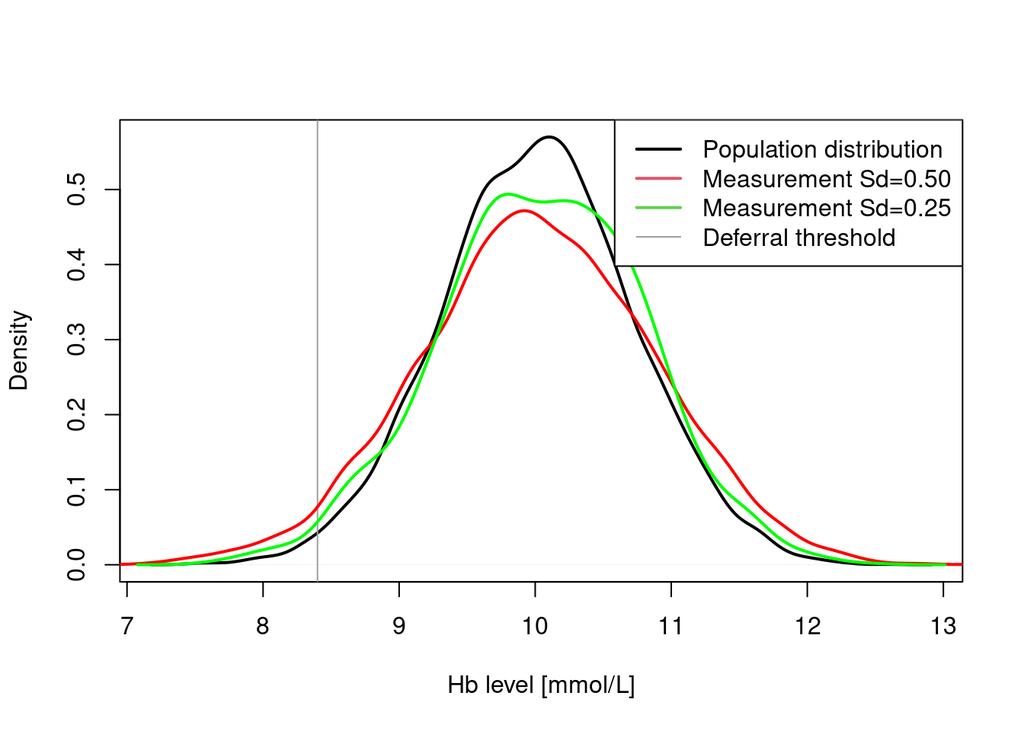

Figure 1: Population Hb distribution and measured Hb distribution for different levels of measurement error (Sd of 0.50 and 0.25 mmol/L respectively).

```r
  plot(density(data_train$true), lwd=2, main="", xlab="Hb level [mmol/L]")
  abline(v=threshold,col=8)
  dens<-density(data_train$meas1, bw=.13)
  lines(dens$x,dens$y, col="red", lwd=2)
  MeasSd<-MeasSds[2]
  createNewTestDataset()
  dens<-density(data_test$meas1, bw=.17)
  lines(dens$x,dens$y, col="green", lwd=2)
  MeasSd<-MeasSds[1]
  createNewTestDataset()
  legend("topright", c("Population distribution",paste0("Measurement Sd=", fix_decimals(MeasSds[1],2)),paste0("Measurement Sd=", MeasSds[2]), "Deferral threshold"),
         lty=c(1,1,1,1), col=c(1,2,3,8), lwd=c(2,2,2,1))
```